# Tidyverse Data Manipulation

Kateřina Večerková

2025-06-19

# `tidyverse` data manipulation

The `tidyverse` is a collection of R packages developed for data science. All `tidyverse` packages share underlying ideas, syntax and data structures, making them highly interopable. The `tidyverse` simplifies many common data manipulation, visualization and analysis tasks. `tidyverse` packages include: - `readr`: data import - `dplyr`: data manipulation - `tidyr`: data tidying - `ggplot2`: data visualization - `forcats`: categorical data manipulation - `stringr`: string manipulation - `lubridate`: date and time manipulation - `tibble`: modern data frames - `purrr`: functional programming

To install the complete tidyverse, use

```r
install.packages("tidyverse")
library(tidyverse)
```

## Loading data from files with readr

The `readr` R package offers functions for importing and exporting tabular data in various formats, such as comma-separated values (CSV), tab-separated values (TSV), and other delimiter-separated files.

```bash
head iris.csv
```

```
## "sepal.length","sepal.width","petal.length","petal.width","variety"
## 5.1,3.5,1.4,.2,"setosa"
## 4.9,3,1.4,.2,"setosa"
## 4.7,3.2,1.3,.2,"setosa"
## 4.6,3.1,1.5,.2,"setosa"
## 5,3.6,1.4,.2,"setosa"
## 5.4,3.9,1.7,.4,"setosa"
## 4.6,3.4,1.4,.3,"setosa"
## 5,3.4,1.5,.2,"setosa"
## 4.4,2.9,1.4,.2,"setosa"
```

CSV, which stands for comma-separated values, is a widely used format for storing tabular data. The first row typically contains the column names, and each subsequent row contains the corresponding data values separated by commas. We’re gonna load this dataset form the file `iris.csv` to R.

```r
# import the readr package
library(readr)
# load the csv dataset
iris <- readr::read_csv("iris.csv")
# let's look at the first 5 rows
head(iris)
```

[output not shown]

Another widely used format is TSV, or tab-separated values. In this case the delimier of columns isn’t a comma, but a tab `\t`.

```r
# laod the tsv dataset
iris <- readr::read_tsv("iris.tsv")
head(iris)
```

```
## # A tibble: 6 × 5
##   sepal.length sepal.width petal.length petal.width variety
##          <dbl>       <dbl>        <dbl>       <dbl> <chr>
## 1          5.1         3.5          1.4         0.2 setosa
## 2          4.9         3            1.4         0.2 setosa
## 3          4.7         3.2          1.3         0.2 setosa
## 4          4.6         3.1          1.5         0.2 setosa
## 5          5           3.6          1.4         0.2 setosa
## 6          5.4         3.9          1.7         0.4 setosa
```

## Manipulating data with dplyr

```r
library(dplyr)
```

### 1. Filtering Rows

Filter the dataset to include only rows where the species is “setosa”.

```r
setosa_iris <- iris %>% dplyr::filter(variety == "setosa")
head(setosa_iris)
```

```
## # A tibble: 6 × 5
##   sepal.length sepal.width petal.length petal.width variety
##          <dbl>       <dbl>        <dbl>       <dbl> <chr>
## 1          5.1         3.5          1.4         0.2 setosa
## 2          4.9         3            1.4         0.2 setosa
## 3          4.7         3.2          1.3         0.2 setosa
## 4          4.6         3.1          1.5         0.2 setosa
## 5          5           3.6          1.4         0.2 setosa
## 6          5.4         3.9          1.7         0.4 setosa
```

Notice the %>% (pipe) operator, it expresses a sequence of multiple operations. Also it is not necessary to put the package before the function, here I explicitly wrote it to demonstrate the use of different tidyverse packages.

### 2. Selecting Columns

Select only the columns for sepal length and sepal width.

```r
sepal_data <- iris %>% dplyr::select(sepal.length, sepal.width)
head(sepal_data)
```

```
## # A tibble: 6 × 2
##   sepal.length sepal.width
##          <dbl>       <dbl>
## 1          5.1         3.5
## 2          4.9         3
## 3          4.7         3.2
## 4          4.6         3.1
## 5          5           3.6
## 6          5.4         3.9
```

### 3. Adding New Columns

Create a new column that is the ratio of petal length and petal width.

```r
iris <- iris %>% dplyr::mutate(petal.ratio = petal.length / petal.width)
head(iris)
```

```
## # A tibble: 6 × 6
##   sepal.length sepal.width petal.length petal.width variety petal.ratio
##          <dbl>       <dbl>        <dbl>       <dbl> <chr>         <dbl>
## 1          5.1         3.5          1.4         0.2 setosa         7
## 2          4.9         3            1.4         0.2 setosa         7
## 3          4.7         3.2          1.3         0.2 setosa         6.5
## 4          4.6         3.1          1.5         0.2 setosa         7.5
## 5          5           3.6          1.4         0.2 setosa         7
## 6          5.4         3.9          1.7         0.4 setosa         4.25
```

### 4. Summarizing data

Calculate the mean and standard deviation of sepal length for each species.

```r
summary_stats <- iris %>% dplyr::group_by(variety) %>% dplyr::summarize(mean_sepal.length = mean(sepal.length), sd_sepal.length = sd(sepal.length))
summary_stats
```

```
## # A tibble: 3 × 3
##   variety    mean_sepal.length sd_sepal.length
##   <chr>                  <dbl>           <dbl>
## 1 setosa                  5.01           0.352
## 2 versicolor              5.94           0.516
## 3 virginica               6.59           0.636
```

### 5. Arranging rows

Arrange the dataset by sepal length in descending order.

```r
sorted_iris <- iris %>% dplyr::arrange(desc(sepal.length))
head(sorted_iris)
```

```
## # A tibble: 6 × 6
##   sepal.length sepal.width petal.length petal.width variety   petal.ratio
##          <dbl>       <dbl>        <dbl>       <dbl> <chr>           <dbl>
## 1          7.9         3.8          6.4         2   virginica        3.2
## 2          7.7         3.8          6.7         2.2 virginica        3.05
## 3          7.7         2.6          6.9         2.3 virginica        3
## 4          7.7         2.8          6.7         2   virginica        3.35
## 5          7.7         3            6.1         2.3 virginica        2.65
## 6          7.6         3            6.6         2.1 virginica        3.14
```

### 6. Grouping and Summarizing

For each species, count the number of instances where petal length is greater than 4.

```r
count_petal_length <- iris %>% dplyr::filter(petal.length > 4) %>% dplyr::group_by(variety) %>% dplyr::summarize(count = n())
count_petal_length
```

```
## # A tibble: 2 × 2
##   variety    count
##   <chr>      <int>
## 1 versicolor    34
## 2 virginica     50
```

### 7. Renaming Columns

Rename the columns sepal.length and sepal.width to sepal_length and sepal_width.

```r
iris <- iris %>% dplyr::rename(sepal_length=sepal.length, sepal_width=sepal.width)
colnames(iris)
```

```
## [1] "sepal_length" "sepal_width"  "petal.length" "petal.width"  "variety"
## [6] "petal.ratio"
```

### 8. Filtering and Mutating

Filter the dataset to include only the “virginica” species and ten add a column indicating whether sepal length is greater than 6.

```r
virginica_iris <- iris %>% dplyr::filter(variety == "virginica") %>% dplyr::mutate(sepal_length_over_6 = sepal_length > 6)
head(virginica_iris)
```

```
## # A tibble: 6 × 7
##   sepal_length sepal_width petal.length petal.width variety   petal.ratio
##          <dbl>       <dbl>        <dbl>       <dbl> <chr>           <dbl>
## 1          6.3         3.3          6           2.5 virginica        2.4
## 2          5.8         2.7          5.1         1.9 virginica        2.68
## 3          7.1         3            5.9         2.1 virginica        2.81
## 4          6.3         2.9          5.6         1.8 virginica        3.11
## 5          6.5         3            5.8         2.2 virginica        2.64
## 6          7.6         3            6.6         2.1 virginica        3.14
## # ℹ 1 more variable: sepal_length_over_6 <lgl>
```

### 9. Sampling Rows

Randomly sample 10 rows from the dataset.

```r
sampled_iris <- iris %>% dplyr::sample_n(10)
show(sampled_iris)
```

```
## # A tibble: 10 × 6
##    sepal_length sepal_width petal.length petal.width variety    petal.ratio
##           <dbl>       <dbl>        <dbl>       <dbl> <chr>            <dbl>
##  1          4.9         3.1          1.5         0.2 setosa            7.5
##  2          6           2.2          4           1   versicolor        4
##  3          5.5         4.2          1.4         0.2 setosa            7
##  4          5.8         2.8          5.1         2.4 virginica         2.12
##  5          5.6         2.9          3.6         1.3 versicolor        2.77
##  6          7.6         3            6.6         2.1 virginica         3.14
##  7          5           3.5          1.3         0.3 setosa            4.33
##  8          4.7         3.2          1.6         0.2 setosa            8
##  9          6.1         3            4.9         1.8 virginica         2.72
## 10          5           3.6          1.4         0.2 setosa            7
```

### 10. Combining Multiple dplyr Functions

Create a new dataset that includes only the “versicolor” species, select only the petal length and petal width columns, then arrange the data by petal width in ascending order.

```r
versicolor_sorted <- iris %>% dplyr::filter(variety == "versicolor") %>% dplyr::select(petal.length, petal.width) %>% dplyr::arrange(petal.width)
head(versicolor_sorted)
```

```
## # A tibble: 6 × 2
##   petal.length petal.width
##          <dbl>       <dbl>
## 1          3.3           1
## 2          3.5           1
## 3          4             1
## 4          4.1           1
## 5          3.5           1
## 6          3.7           1
```

## Tidying data with tidyr

#### **Wide Format**

In the wide format, each variable is spread out across multiple columns, and each observation (or unit) is represented by a single row.

**Example with the `iris` dataset:** In its original wide format, the `iris` dataset looks like this:

| Species | Sepal.Length | Sepal.Width | Petal.Length | Petal.Width |
| --- | --- | --- | --- | --- |
| setosa | 5.1 | 3.5 | 1.4 | 0.2 |
| versicolor | 7.0 | 3.2 | 4.7 | 1.4 |
| virginica | 6.3 | 3.3 | 6.0 | 2.5 |

Here, each column represents a different variable (e.g., `Sepal.Length`, `Sepal.Width`), and each row represents an observation.

#### **Long Format**

In the long format, each row corresponds to a single observation of a variable, with one column for the variable names and another for the variable values. This format is often more suitable for analysis and plotting, especially when using packages like `ggplot2`.

**Example of converting the `iris` dataset to long format:**

| Species | Measurement | Value |
| --- | --- | --- |
| setosa | Sepal.Length | 5.1 |
| setosa | Sepal.Width | 3.5 |
| setosa | Petal.Length | 1.4 |
| setosa | Petal.Width | 0.2 |
| versicolor | Sepal.Length | 7.0 |
| versicolor | Sepal.Width | 3.2 |
| … | … | … |

Here, the variables `Sepal.Length`, `Sepal.Width`, `Petal.Length`, and `Petal.Width` are consolidated into a single column called `Measurement`, with the corresponding values in another column called `Value`. Each unique combination of `Species` and `Measurement` has its own row.

#### **Differences and Use Cases**

- **Wide Format:**
  - Easier to view and understand when there are a small number of variables.
  - Each row represents a single unit or observation.
  - Suitable for certain types of statistical modeling or when data is naturally structured this way.
- **Long Format:**
  - More efficient for data manipulation, aggregation, and visualization, especially when using tools that work well with this structure (e.g., `ggplot2` for plotting).
  - Useful for datasets with multiple measurements per observation or when the number of variables is large.
  - Easier to filter, group, and apply functions across different variables.

### 1. Pivoting Longer

Convert the dataset into a longer format with columns measurement and value, where measurement includes the variable names (sepal length, sepal width, petal length, petal width) and value contains the corresponding measurements.

```r
# unify column names
iris <- iris %>% dplyr::rename(petal_length = petal.length, petal_width = petal.width, petal_ratio = petal.ratio)

# convert to long format
iris_long <- iris %>% tidyr::pivot_longer(cols = c(sepal_length, sepal_width, petal_length, petal_width),
               names_to = "Measurement",
               values_to = "Value")

head(iris_long)
```

```
## # A tibble: 6 × 4
##   variety petal_ratio Measurement  Value
##   <chr>         <dbl> <chr>        <dbl>
## 1 setosa            7 sepal_length   5.1
## 2 setosa            7 sepal_width    3.5
## 3 setosa            7 petal_length   1.4
## 4 setosa            7 petal_width    0.2
## 5 setosa            7 sepal_length   4.9
## 6 setosa            7 sepal_width    3
```

### 2. Pivoting Wider

Take the dataset and pivot it back to original wide format.

```r
iris_wide <- iris_long %>% tidyr::pivot_wider(names_from = Measurement, values_from = Value)
head(iris_wide)
```

```
## # A tibble: 6 × 6
##   variety petal_ratio sepal_length sepal_width petal_length petal_width
##   <chr>         <dbl> <list>       <list>      <list>       <list>
## 1 setosa         7    <dbl [8]>    <dbl [8]>   <dbl [8]>    <dbl [8]>
## 2 setosa         6.5  <dbl [4]>    <dbl [4]>   <dbl [4]>    <dbl [4]>
## 3 setosa         7.5  <dbl [7]>    <dbl [7]>   <dbl [7]>    <dbl [7]>
## 4 setosa         4.25 <dbl [1]>    <dbl [1]>   <dbl [1]>    <dbl [1]>
## 5 setosa         4.67 <dbl [3]>    <dbl [3]>   <dbl [3]>    <dbl [3]>
## 6 setosa        15    <dbl [2]>    <dbl [2]>   <dbl [2]>    <dbl [2]>
```

### 3. Separating Columns

Create a new dataset from iris where the variety column is split into two new columns: genus and species_type. Assume the first four letters represent the genus and the rest is the species type.

```r
iris_separated <- iris %>% tidyr::separate(variety, into = c("genus", "species_type"), sep = 4)
head(iris_separated)
```

```
## # A tibble: 6 × 7
##   sepal_length sepal_width petal_length petal_width genus species_type
##          <dbl>       <dbl>        <dbl>       <dbl> <chr> <chr>
## 1          5.1         3.5          1.4         0.2 seto  sa
## 2          4.9         3            1.4         0.2 seto  sa
## 3          4.7         3.2          1.3         0.2 seto  sa
## 4          4.6         3.1          1.5         0.2 seto  sa
## 5          5           3.6          1.4         0.2 seto  sa
## 6          5.4         3.9          1.7         0.4 seto  sa
## # ℹ 1 more variable: petal_ratio <dbl>
```

### 4. Uniting Columns

Combine the sepal_length and sepal_width columns into a single column called sepal_dimensions with values separated by an underscore.

```r
iris_united <- iris %>% tidyr::unite(sepal_dimensions, sepal_length, sepal_width, sep = "_")
head(iris_united)
```

```
## # A tibble: 6 × 5
##   sepal_dimensions petal_length petal_width variety petal_ratio
##   <chr>                   <dbl>       <dbl> <chr>         <dbl>
## 1 5.1_3.5                   1.4         0.2 setosa         7
## 2 4.9_3                     1.4         0.2 setosa         7
## 3 4.7_3.2                   1.3         0.2 setosa         6.5
## 4 4.6_3.1                   1.5         0.2 setosa         7.5
## 5 5_3.6                     1.4         0.2 setosa         7
## 6 5.4_3.9                   1.7         0.4 setosa         4.25
```

### 5. Dropping NA values

NA values are values missing from the dataset. Removal of NAs is a routine part of dataset pre-processing. In this exercise, we’re gonna replace some values with NAs to obtain a more realistic dataset and then we’re gonna remove rows with any missing values.

```r
set.seed(42) # for reproducibility

# introduce some NA values
iris_na <- iris %>% dplyr::mutate(sepal_length = replace(sepal_length, sample(1:n(), 10), NA))

# look at the introdued NAs
iris_na %>% dplyr::filter(is.na(sepal_length))
```

```
## # A tibble: 10 × 6
##    sepal_length sepal_width petal_length petal_width variety    petal_ratio
##           <dbl>       <dbl>        <dbl>       <dbl> <chr>            <dbl>
##  1           NA         3.3          1.7         0.5 setosa            3.4
##  2           NA         3.8          1.6         0.2 setosa            8
##  3           NA         3.7          1.5         0.2 setosa            7.5
##  4           NA         2.9          3.6         1.3 versicolor        2.77
##  5           NA         3.2          4.8         1.8 versicolor        2.67
##  6           NA         2.8          4.7         1.2 versicolor        3.92
##  7           NA         2.8          4.9         2   virginica         2.45
##  8           NA         3            4.9         1.8 virginica         2.72
##  9           NA         3            5.2         2.3 virginica         2.26
## 10           NA         3            5.1         1.8 virginica         2.83
```

```r
iris_no_na <- iris_na %>% tidyr::drop_na()

# filter out rows with NAs in sepal_length
iris_no_na %>% dplyr::filter(is.na(sepal_length))
```

```
## # A tibble: 0 × 6
## # ℹ 6 variables: sepal_length <dbl>, sepal_width <dbl>, petal_length <dbl>,
## #   petal_width <dbl>, variety <chr>, petal_ratio <dbl>
```

### 6. Replacing NA Values

In the iris_na dataset from previous example, replace the NA values in the sepal_length column with mean non-NA values of the sepal_length column.

```r
# calculate the man of the sepal_length column
mean_sepal_length <- mean(iris_na$sepal_length, na.rm = TRUE)
# replace NAs with the mean
iris_replaced_na <- iris_na %>% tidyr::replace_na(list(sepal_length = mean_sepal_length))
# check if NAs got replaced
iris_replaced_na %>% dplyr::filter(is.na(sepal_length))
```

```
## # A tibble: 0 × 6
## # ℹ 6 variables: sepal_length <dbl>, sepal_width <dbl>, petal_length <dbl>,
## #   petal_width <dbl>, variety <chr>, petal_ratio <dbl>
```

## Data visualization with ggplot2

```r
library(ggplot2)
```

### 1. Basic Scatter Plot

Create a scatter plot of sepal length vs sepal width and color the points by variety.

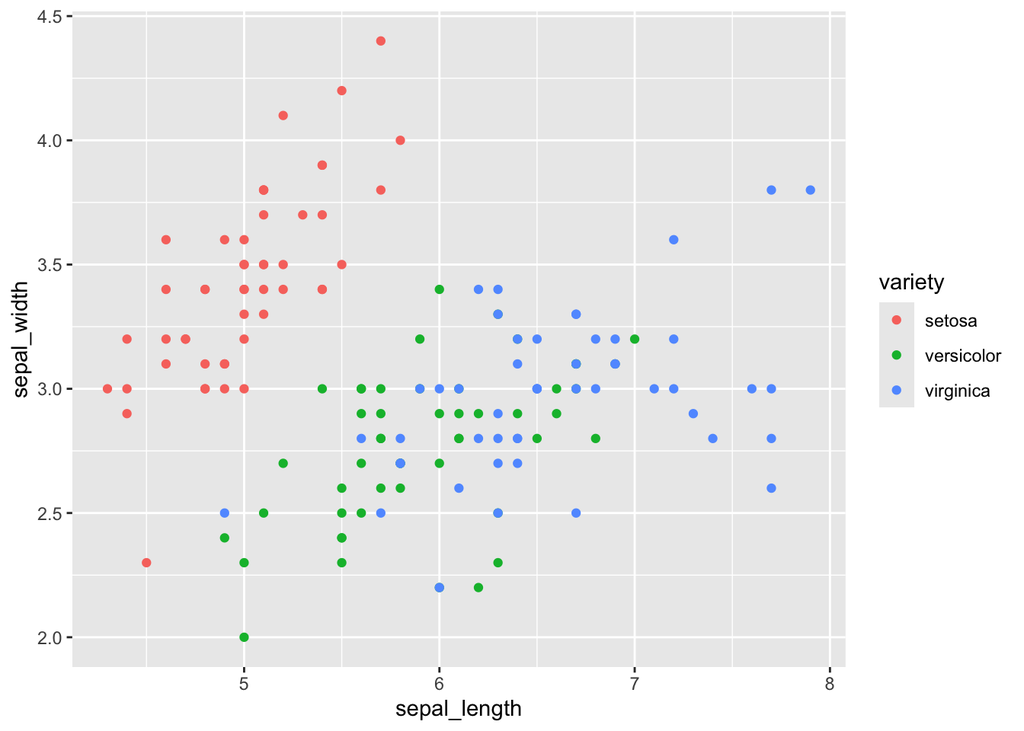

```r
ggplot(iris, aes(x = sepal_length, y = sepal_width, color = variety)) + geom_point()
```

### 2. Adding Titles and Labels

Modify the scatter plot to include a title and x-axis and y-axis label.

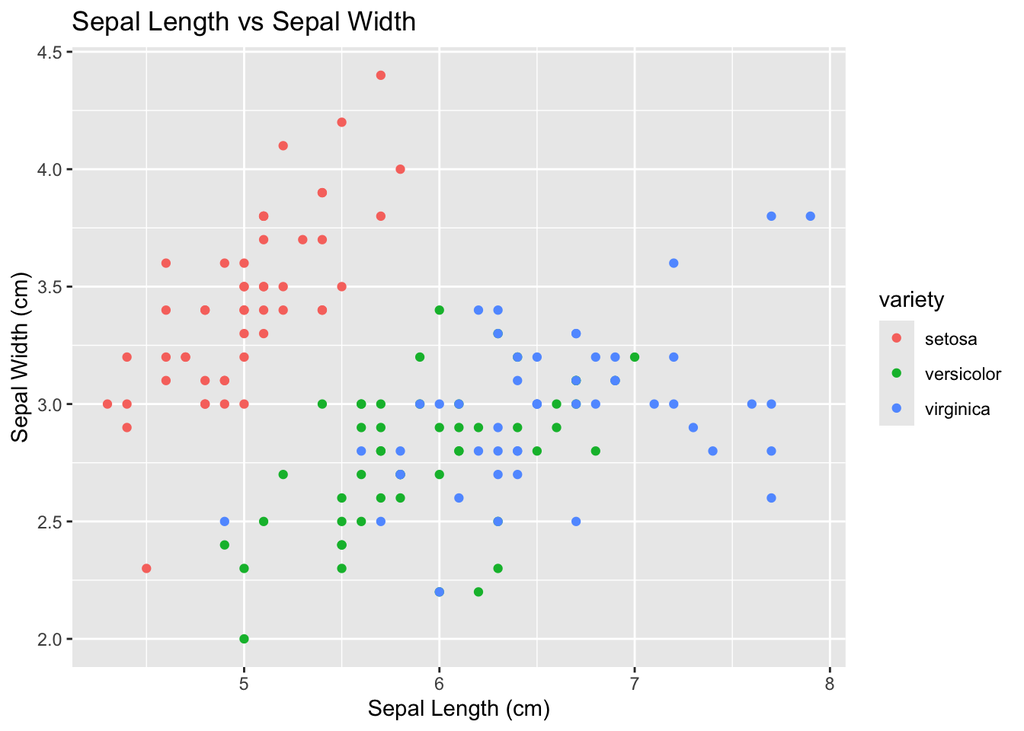

```r
ggplot(iris, aes(x = sepal_length, y = sepal_width, color = variety)) +
  geom_point() +
  ggtitle("Sepal Length vs Sepal Width") +
  xlab("Sepal Length (cm)") +
  ylab("Sepal Width (cm)")
```

### 3. Histogram

Create a histogram of petal length and use different colors to represent different variety.

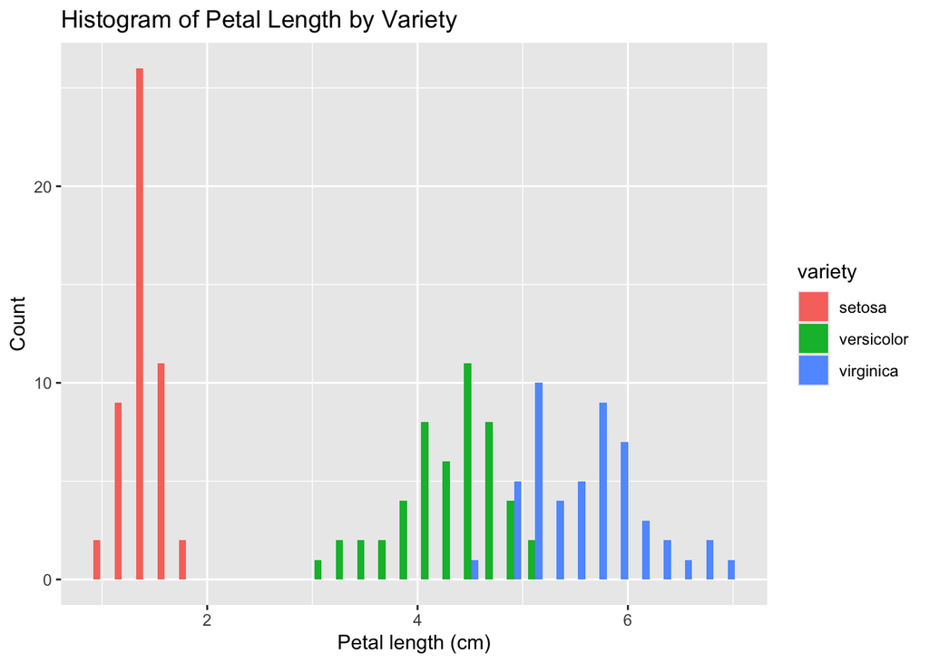

```r
ggplot(iris, aes(x = petal_length, fill = variety)) +
  geom_histogram(position = "dodge", bins = 30) +
  xlab("Petal length (cm)") +
  ylab("Count") +
  ggtitle("Histogram of Petal Length by Variety")
```

### 4. Box Plot

Create a box plot of sepal length for each variety.

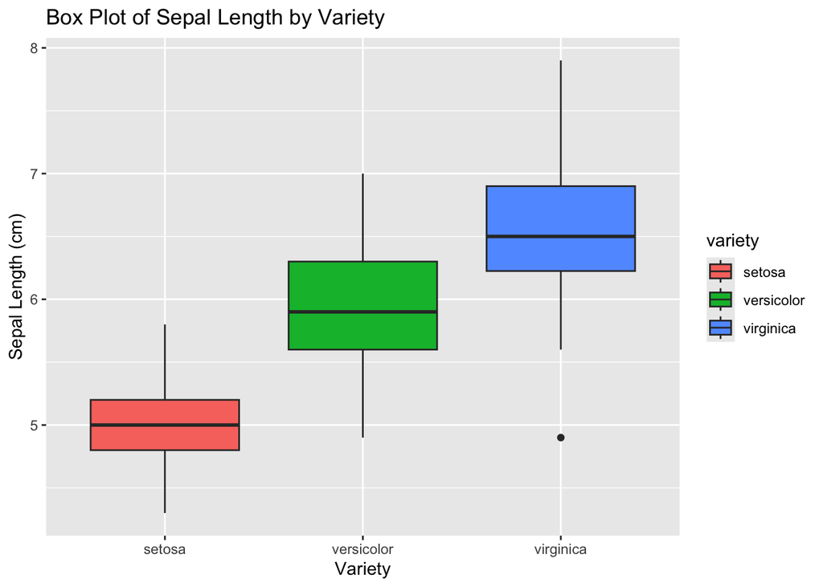

```r
ggplot(iris, aes(x = variety, y = sepal_length, fill = variety)) +
  geom_boxplot() +
  ggtitle("Box Plot of Sepal Length by Variety") +
  xlab("Variety") +
  ylab("Sepal Length (cm)")
```

### 5. Facet Grid

Use facetting to create separate scatter plots of petal length vs. petal width for each variety.

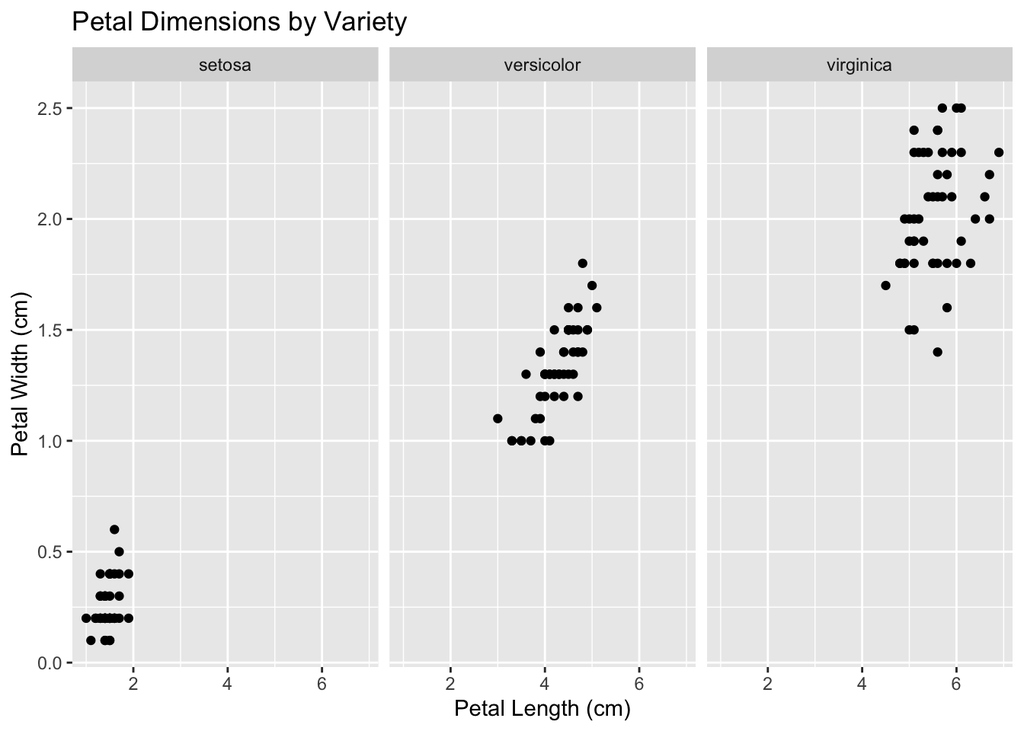

```r
ggplot(iris, aes(x = petal_length, y = petal_width)) +
  geom_point() +
  facet_grid(. ~ variety) +
  ggtitle("Petal Dimensions by Variety") +
  xlab("Petal Length (cm)") +
  ylab("Petal Width (cm)")
```

### 6. Density Plot

Create a density plot for sepal width for each variety, using different colors.

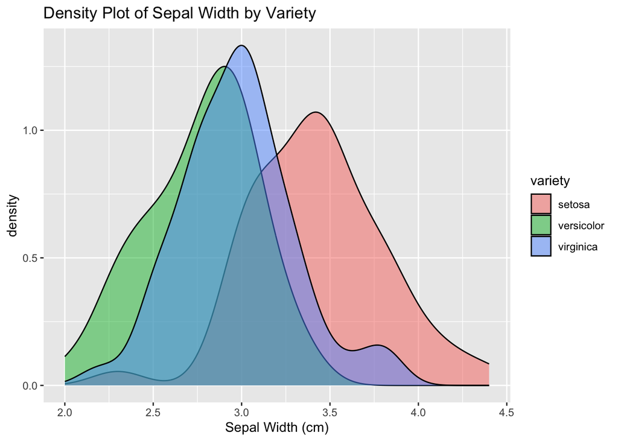

```r
ggplot(iris, aes(x = sepal_width, fill = variety)) +
  geom_density(alpha = 0.5) + # the alpha parameter regulates color transparency and it ranges between 0.0 (fully transparent) and 1.0 (fully opaque)
  ggtitle("Density Plot of Sepal Width by Variety") +
  xlab("Sepal Width (cm)")
```

### 7. Line Plot

Generate a line plot to show the average petal length by variety.

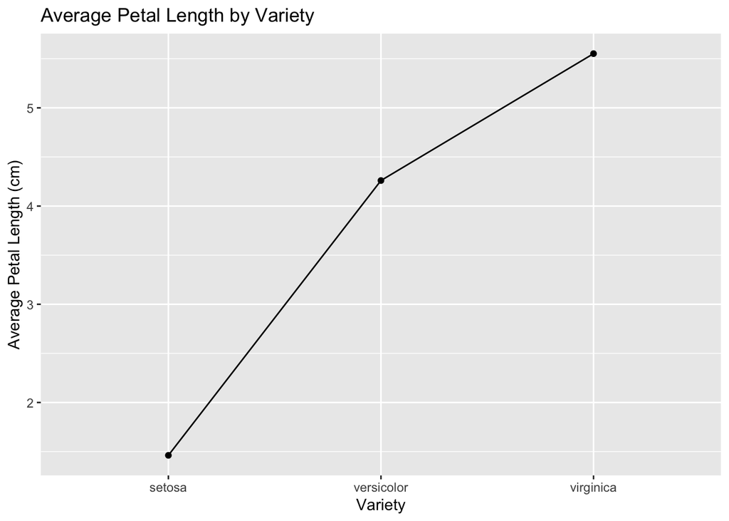

```r
iris_avg <- iris %>%
  group_by(variety) %>%
  summarize(avg_petal_length = mean(petal_length))

ggplot(iris_avg, aes(x = variety, y = avg_petal_length, group = 1)) +
  geom_line() +
  geom_point() +
  ggtitle("Average Petal Length by Variety") +
  xlab("Variety") +
  ylab("Average Petal Length (cm)")
```

### 8. Bar Chart

Create a bar chart showing the count of observations for each variety.

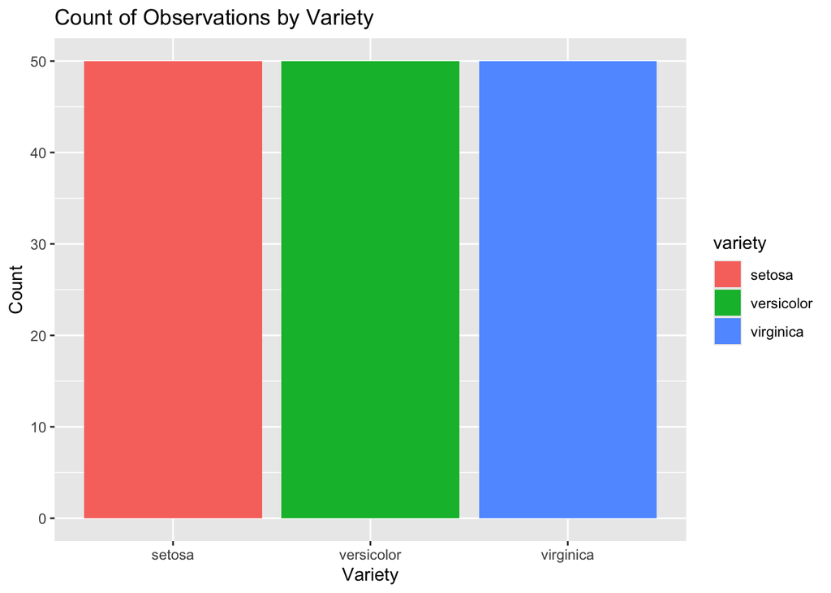

```r
ggplot(iris, aes(x = variety, fill = variety)) +
  geom_bar() +
  ggtitle("Count of Observations by Variety") +
  xlab("Variety") +
  ylab("Count")
```

### 9. Customizing Plot Themes

Customize a scatter plot with sepal length vs petal length to use a minimal theme and change the legend position.

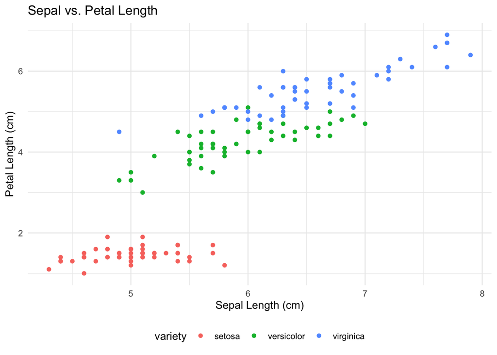

```r
ggplot(iris, aes(x = sepal_length, y = petal_length, color = variety)) +
  geom_point() +
  theme_minimal() +
  theme(legend.position = "bottom") +
  ggtitle("Sepal vs. Petal Length") +
  xlab("Sepal Length (cm)") +
  ylab("Petal Length (cm)")
```

## Working with categorical data with `forcats`

For this part we will use the `diamonds` dataset which has more columns with categorical data, namely cut, color, clarity.

```r
library(ggplot2)
diamonds$color
```

[output not shown]

[output cut: 1485 more lines]

### 1. Reordering Factor Levels by Median Price

Reorder the `cut` factor levels in the `diamonds` dataset by the median `price` of diamonds in each `cut` category, in descending order.

```r
levels(diamonds$cut)
```

```
## [1] "Fair"      "Good"      "Very Good" "Premium"   "Ideal"
```

```r
diamonds$cut <- forcats::fct_reorder(diamonds$cut, diamonds$price, .fun = median, .desc = TRUE)

levels(diamonds$cut)
```

```
## [1] "Fair"      "Premium"   "Good"      "Very Good" "Ideal"
```

### 2. Lump Rare Levels in `color`

Lump the least common levels of the `color` factor into an “Other” category, keeping only the top 4 most common colors distinct.

```r
levels(diamonds$color)
```

```
## [1] "D" "E" "F" "G" "H" "I" "J"
```

```r
diamonds$color <- forcats::fct_lump_n(diamonds$color, n = 4)

levels(diamonds$color)
```

```
## [1] "E"     "F"     "G"     "H"     "Other"
```

### 3. Collapsing Levels of `clarity`

Combine the `clarity` levels into broader categories:

- “Low” for I1, SI2, SI1
- “Medium” for VS2, VS1
- “High” for VVS2, VVS1, IF

```r
levels(diamonds$clarity)
```

```
## [1] "I1"   "SI2"  "SI1"  "VS2"  "VS1"  "VVS2" "VVS1" "IF"
```

```r
diamonds$clarity <- forcats::fct_collapse(diamonds$clarity,
                                 Low = c("I1", "SI2", "SI1"),
                                 Medium = c("VS2", "VS1"),
                                 High = c("VVS2", "VVS1", "IF"))

levels(diamonds$clarity)
```

```
## [1] "Low"    "Medium" "High"
```

### 4. Renaming Factor Levels

Rename the cut factor levels to more descriptive names:

- “Fair” to “Fair Cut”
- “Good” to “Good Cut”
- “Very Good” to “Very Good Cut”
- “Premium” to “Premium Cut”
- “Ideal” to “Ideal Cut”

```r
diamonds$cut <- forcats::fct_recode(diamonds$cut,
                           "Fair Cut" = "Fair",
                           "Good Cut" = "Good",
                           "Very Good Cut" = "Very Good",
                           "Premium Cut" = "Premium",
                           "Ideal Cut" = "Ideal")

levels(diamonds$cut)
```

```
## [1] "Fair Cut"      "Premium Cut"   "Good Cut"      "Very Good Cut"
## [5] "Ideal Cut"
```

### 5. Reverse Order of Levels

Reverse the order of the levels in the `clarity` factor.

```r
levels(diamonds$clarity)
```

```
## [1] "Low"    "Medium" "High"
```

```r
diamonds$clarity <- forcats::fct_rev(diamonds$clarity)

levels(diamonds$clarity)
```

```
## [1] "High"   "Medium" "Low"
```

### 6. Dropping Unused Levels

```r
diamonds_subset <- diamonds %>%
  dplyr::filter(cut %in% c("Premium", "Ideal"))

diamonds_subset$cut <- forcats::fct_drop(diamonds_subset$cut)

levels(diamonds_subset$cut)
```

```
## character(0)
```

### 7. Convert a Numeric Variable to a Factor

Convert the `carat` variable into a categorical factor by binning it into intervals:

- 0.0-0.5 carats
- 0.5-1.0 carats
- 1.0-1.5 carats
- 1.5-2.0 carats
- 2.0+ carats

```r
diamonds$carat_bin <- cut(diamonds$carat,
                          breaks = c(0, 0.5, 1, 1.5, 2, Inf),
                          labels = c("0-0.5", "0.5-1.0", "1.0-1.5", "1.5-2.0", "2.0+"))

levels(diamonds$carat_bin)
```

```
## [1] "0-0.5"   "0.5-1.0" "1.0-1.5" "1.5-2.0" "2.0+"
```

## String Manipulation with `stringr`

```r
library(stringr)
```

### 1. Detecting Patterns in Strings

Find all rows in the `diamonds` dataset where the `cut` contains the substring “Good”

```r
good_cut_diamonds <- diamonds[stringr::str_detect(diamonds$cut, "Good"), ]
head(good_cut_diamonds)
```

```
## # A tibble: 6 × 11
##   carat cut          color clarity depth table price     x     y     z carat_bin
##   <dbl> <ord>        <ord> <ord>   <dbl> <dbl> <int> <dbl> <dbl> <dbl> <fct>
## 1  0.23 Good Cut     E     Medium   56.9    65   327  4.05  4.07  2.31 0-0.5
## 2  0.31 Good Cut     Other Low      63.3    58   335  4.34  4.35  2.75 0-0.5
## 3  0.24 Very Good C… Other High     62.8    57   336  3.94  3.96  2.48 0-0.5
## 4  0.24 Very Good C… Other High     62.3    57   336  3.95  3.98  2.47 0-0.5
## 5  0.26 Very Good C… H     Low      61.9    55   337  4.07  4.11  2.53 0-0.5
## 6  0.23 Very Good C… H     Medium   59.4    61   338  4     4.05  2.39 0-0.5
```

### 2. Extracting Parts of a String

Create a string vector of diamond IDs in the format “Diamond_ID-XXXXX”, where “XXXXX” is the row number. Then, extract just the numeric ID part from these strings.

```r
diamond_ids <- str_c("Diamond_ID-", rownames(diamonds))
extracted_ids <- stringr::str_extract(diamond_ids, "\\d+")
head(extracted_ids)
```

```
## [1] "1" "2" "3" "4" "5" "6"
```

### 3. Replacing Substring

Replace all instances of “Good” in the `cut` column with “Decent”

```r
head(diamonds$cut)
```

```
## [1] Ideal Cut     Premium Cut   Good Cut      Premium Cut   Good Cut
## [6] Very Good Cut
## Levels: Fair Cut < Premium Cut < Good Cut < Very Good Cut < Ideal Cut
```

```r
diamonds$cut <- stringr::str_replace(diamonds$cut, "Good", "Decent")
head(diamonds$cut)
```

```
## [1] "Ideal Cut"       "Premium Cut"     "Decent Cut"      "Premium Cut"
## [5] "Decent Cut"      "Very Decent Cut"
```

### 4. Splitting Strings

Split a hypothetical column of carat weights stored as a string with a unit (e.g., “1.5 carats”) into numeric and unit components.

```r
carat_strings <- c("1.5 carats", "2.0 carats", "0.9 carats")
split_carat <- stringr::str_split(carat_strings, " ", simplify = TRUE)
carat_values <- as.numeric(split_carat[, 1])
carat_units <- split_carat[, 2]

head(carat_values)
```

```
## [1] 1.5 2.0 0.9
```

```r
head(carat_units)
```

```
## [1] "carats" "carats" "carats"
```

### 5. String Length

Calculate the number of characters in each level of the `cut` column

```r
cut_lengths <- stringr::str_length(diamonds$cut)
head(cut_lengths)
```

```
## [1]  9 11 10 11 10 15
```

### 6. Combining Strings

Combine the `cut`, `color` and `clarity` columns into a single string, separated by hyphensm to create a unique identifier for each diamond

```r
diamond_id <- stringr::str_c(diamonds$cut, diamonds$color, diamonds$clarity, sep = "-")
head(diamond_id)
```

```
## [1] "Ideal Cut-E-Low"            "Premium Cut-E-Low"
## [3] "Decent Cut-E-Medium"        "Premium Cut-Other-Medium"
## [5] "Decent Cut-Other-Low"       "Very Decent Cut-Other-High"
```

### 7. Detecting Digits

Create a vector of mixed strings and identify which ones contain numeric digits

```r
mixed_strings <- c("carat 2.5", "weight", "price $500", "value 1000")
contains_digits <- stringr::str_detect(mixed_strings, "\\d")
contains_digits
```

```
## [1]  TRUE FALSE  TRUE  TRUE
```

### 8. Trimming Whitespace

Remove leading and trailing whitespace from a vector of strings representing diamond descriptions

```r
diamond_descriptions <- c("  Ideal Cut  ", "  Premium Quality ", "Fair Cut ")
trimmed_descriptions <- stringr::str_trim(diamond_descriptions)
trimmed_descriptions
```

```
## [1] "Ideal Cut"       "Premium Quality" "Fair Cut"
```

### 9. Counting Substring Occurences

Count how many times the letter “e” appears in the `cut` column across the entire dataset

```r
e_count <- stringr::str_count(diamonds$cut, "e")
total_e_count <- sum(e_count)
total_e_count
```

```
## [1] 81400
```

### 10. Repeating Strings

```r
repeated_string <- stringr::str_dup("Diamond", 5)
repeated_string
```

```
## [1] "DiamondDiamondDiamondDiamondDiamond"
```

### 11. Changing Case

Covert the `color` column in the `diamonds` dataset to uppercase

```r
head(diamonds$color)
```

```
## [1] E     E     E     Other Other Other
## Levels: E < F < G < H < Other
```

```r
diamonds$color <- stringr::str_to_upper(diamonds$color)
head(diamonds$color)
```

```
## [1] "E"     "E"     "E"     "OTHER" "OTHER" "OTHER"
```

### 12. Subsetting Strings

Taken the first three characters from each value in the `clarity` column

```r
clarity_subset <- stringr::str_sub(diamonds$clarity, 1, 3)
head(clarity_subset)
```

```
## [1] "Low" "Low" "Med" "Med" "Low" "Hig"
```

### 13. Padding Strings

Create a column of diamond IDs (like in Exercise 2) and pad them with zeros on the left so that all IDs have five digits

```r
diamond_ids <- stringr::str_pad(row.names(diamonds), width = 5, pad = "0")
head(diamond_ids)
```

```
## [1] "00001" "00002" "00003" "00004" "00005" "00006"
```

## Date and Time Manipualtion with `lubridate`

```r
library(lubridate)
```

### 1. Parsing Dates

Convert the string “2023-08-15” into a date object

```r
date <- lubridate::ymd("2023-08-15")
date
```

```
## [1] "2023-08-15"
```

### 2. Extracting Date Components

From the date “2024-12-25”, extract the year, month, and day

```r
date <- lubridate::ymd("2024-12-25")
year <- lubridate::year(date)
month <- lubridate::month(date)
day <- lubridate::day(date)

year
```

```
## [1] 2024
```

```r
month
```

```
## [1] 12
```

```r
day
```

```
## [1] 25
```

### 3. Handling Different Date Formats

Parse the date “15-August-2023” into a date object

```r
date <- lubridate::dmy("15-August-2023")
date
```

```
## [1] "2023-08-15"
```

### 4. Adding and Subtracting Time Intervals

Add 3 months to the date “2023-01-01” and subtract 10 days from it

```r
date <- lubridate::ymd("2023-01-01")
date_plus_3_months <- date %m+% months(3)
date_minus_10_days <- date - days(10)

date_plus_3_months
```

```
## [1] "2023-04-01"
```

```r
date_minus_10_days
```

```
## [1] "2022-12-22"
```

### 5. Calculating Time Differences

Calculate the number of days between “2023-01-01” and “2024-01-01”

```r
date1 <- lubridate::ymd("2023-01-01")
date2 <- lubridate::ymd("2024-01-01")
days_diff <- as.numeric(difftime(date2, date1, units = "days"))

days_diff
```

```
## [1] 365
```

### 6. Working with Date-Time Objects

Create a date-time object for “2023-08-15 12:34:56”

```r
datetime <- lubridate::ymd_hms("2023-08-15 12:34:56")
datetime
```

```
## [1] "2023-08-15 12:34:56 UTC"
```

### 7. Extracting Time Components

From the date-time “2023-08-15 12:34:56”, extract the hour, minute, and second

```r
datetime <- lubridate::ymd_hms("2023-08-15 12:34:56")
hour <- lubridate::hour(datetime)
minute <- lubridate::minute(datetime)
second <- lubridate::second(datetime)

hour
```

```
## [1] 12
```

```r
minute
```

```
## [1] 34
```

```r
second
```

```
## [1] 56
```

### 8. Rounding Dates

Round the date-time “2023-08-15 12:34:56” to the nearest hour

```r
datetime <- lubridate::ymd_hms("2023-08-15 12:34:56")
rounded_datetime <- lubridate::round_date(datetime, unit = "hour")

rounded_datetime
```

```
## [1] "2023-08-15 13:00:00 UTC"
```

### 9. Finding the Day of the Week

Determine the day of the week for “2023-08-15”

```r
date <- lubridate::ymd("2023-08-15")
day_of_week <- lubridate::wday(date, label = TRUE)

day_of_week
```

```
## [1] Tue
## Levels: Sun < Mon < Tue < Wed < Thu < Fri < Sat
```

### 10. Converting Time Zones

Convert the date-time “2023-08-15 12:34:56” from UTC to the “America/New_York” time zone

```r
datetime_utc <- lubridate::ymd_hms("2023-08-15 12:34:56", tz = "UTC")
datetime_ny <- lubridate::with_tz(datetime_utc, tzone = "America/New_York")

datetime_ny
```

```
## [1] "2023-08-15 08:34:56 EDT"
```

## Modern reimagining of data frames with `tibble`

```r
library(tibble)
```

### 1. Creating a Simple Tibble

Create a tibble with three columns: `Name` (character), `Age` (numeric), and `Height` (numeric)

```r
people <- tibble::tibble(
  Name = c("Alice", "Bob", "Charlie"),
  Age = c(25, 30, 35),
  Height = c(160, 175, 168)
)

people
```

```
## # A tibble: 3 × 3
##   Name      Age Height
##   <chr>   <dbl>  <dbl>
## 1 Alice      25    160
## 2 Bob        30    175
## 3 Charlie    35    168
```

### 2. Adding a New Column to a Tibble

Add a new column `Weight` to the `people` tibble created in Exercise 1

```r
people <- people %>%
  dplyr::mutate(Weight = c(55, 70, 68))

people
```

```
## # A tibble: 3 × 4
##   Name      Age Height Weight
##   <chr>   <dbl>  <dbl>  <dbl>
## 1 Alice      25    160     55
## 2 Bob        30    175     70
## 3 Charlie    35    168     68
```

### 3. Converting a Data Frame to a Tibble

Convert the built-in `mtcars` data frame to a tibble.

```r
mtcars_tibble <- tibble::as_tibble(mtcars)
mtcars_tibble
```

```
## # A tibble: 32 × 11
##      mpg   cyl  disp    hp  drat    wt  qsec    vs    am  gear  carb
##    <dbl> <dbl> <dbl> <dbl> <dbl> <dbl> <dbl> <dbl> <dbl> <dbl> <dbl>
##  1  21       6  160    110  3.9   2.62  16.5     0     1     4     4
##  2  21       6  160    110  3.9   2.88  17.0     0     1     4     4
##  3  22.8     4  108     93  3.85  2.32  18.6     1     1     4     1
##  4  21.4     6  258    110  3.08  3.22  19.4     1     0     3     1
##  5  18.7     8  360    175  3.15  3.44  17.0     0     0     3     2
##  6  18.1     6  225    105  2.76  3.46  20.2     1     0     3     1
##  7  14.3     8  360    245  3.21  3.57  15.8     0     0     3     4
##  8  24.4     4  147.    62  3.69  3.19  20       1     0     4     2
##  9  22.8     4  141.    95  3.92  3.15  22.9     1     0     4     2
## 10  19.2     6  168.   123  3.92  3.44  18.3     1     0     4     4
## # ℹ 22 more rows
```

### 4. Accessing Columns in a Tibble

Access the `mpg` column of the `mtcars_tibble` created in Exercise 3 using the `$` operator.

```r
mpg_column <- mtcars_tibble$mpg
mpg_column
```

```
##  [1] 21.0 21.0 22.8 21.4 18.7 18.1 14.3 24.4 22.8 19.2 17.8 16.4 17.3 15.2 10.4
## [16] 10.4 14.7 32.4 30.4 33.9 21.5 15.5 15.2 13.3 19.2 27.3 26.0 30.4 15.8 19.7
## [31] 15.0 21.4
```

### 5. Accessing Rows in a Tibble

Access the first 5 rows of the `mtcars_tibble`

```r
first_five_rows <- mtcars_tibble[1:5, ]
first_five_rows
```

```
## # A tibble: 5 × 11
##     mpg   cyl  disp    hp  drat    wt  qsec    vs    am  gear  carb
##   <dbl> <dbl> <dbl> <dbl> <dbl> <dbl> <dbl> <dbl> <dbl> <dbl> <dbl>
## 1  21       6   160   110  3.9   2.62  16.5     0     1     4     4
## 2  21       6   160   110  3.9   2.88  17.0     0     1     4     4
## 3  22.8     4   108    93  3.85  2.32  18.6     1     1     4     1
## 4  21.4     6   258   110  3.08  3.22  19.4     1     0     3     1
## 5  18.7     8   360   175  3.15  3.44  17.0     0     0     3     2
```

### 6. Creating a Tibble with Different Data Types

Create a tibble with a date column, a logical column, and a character column

```r
mixed_tibble <- tibble::tibble(
  Date = as.Date(c("2023-01-01", "2023-01-02", "2023-01-03")),
  Logical = c(TRUE, FALSE, TRUE),
  Category = c("A", "B", "C")
)

mixed_tibble
```

```
## # A tibble: 3 × 3
##   Date       Logical Category
##   <date>     <lgl>   <chr>
## 1 2023-01-01 TRUE    A
## 2 2023-01-02 FALSE   B
## 3 2023-01-03 TRUE    C
```

### 7. Renaming Columns in a Tibble

Rename the columns in the `people` tibble to `Full_Name`, `Age_Years`, and `Height_cm`

```r
people <- people %>%
  dplyr::rename(
    Full_Name = Name,
    Age_Years = Age,
    Height_cm = Height
  )

people
```

```
## # A tibble: 3 × 4
##   Full_Name Age_Years Height_cm Weight
##   <chr>         <dbl>     <dbl>  <dbl>
## 1 Alice            25       160     55
## 2 Bob              30       175     70
## 3 Charlie          35       168     68
```

### 8. Subsetting a Tibble with `filter` and `select`

Subset the `mtcars_tibble` to only include rows where `mpg` is greater than 20 and select only the `mpg`, `hp`, and `wt` columns

```r
filtered_tibble <- mtcars_tibble %>%
  dplyr::filter(mpg > 20) %>%
  dplyr::select(mpg, hp, wt)

filtered_tibble
```

```
## # A tibble: 14 × 3
##      mpg    hp    wt
##    <dbl> <dbl> <dbl>
##  1  21     110  2.62
##  2  21     110  2.88
##  3  22.8    93  2.32
##  4  21.4   110  3.22
##  5  24.4    62  3.19
##  6  22.8    95  3.15
##  7  32.4    66  2.2
##  8  30.4    52  1.62
##  9  33.9    65  1.84
## 10  21.5    97  2.46
## 11  27.3    66  1.94
## 12  26      91  2.14
## 13  30.4   113  1.51
## 14  21.4   109  2.78
```